# Выбор сложности модели через максимизацию производной суммы квадратов остатков

14 мая 2015

## Минимизация суммы квадратов остатков

Простая модель линейной регрессии:

\[ y_i = \beta_1 + \beta_2 x_{i2}+ \ldots + \beta_k x_{ik} + \varepsilon_i \]

МНК: подбираем \(\beta\) минимизируя \(RSS\).

## Проблема с параметром сложности модели

\[ y_i = \beta_1 + \beta_2 x_{i2}+ \ldots + \beta_k x_{ik} + \varepsilon_i \]

Однако нельзя подобрать \(k\) минимизируя \(RSS\).

Чем больше сложность модели, \(k\), тем меньше будет \(RSS\).

## Дилемма сложность–сумма квадратов остатков универсальна

- LASSO
- Ridge-регрессия
- Классификационные деревья
- Ядерная оценка функции плотности
- Ядерная оценка в непараметрической регрессии

…

## Кратко о LASSO

Зафиксируем \(k\).

Минимизируем по \(\beta\) сумму квадратов остатков, оштрафованную на сложность модели: \[ \min RSS + \lambda \cdot (|\beta_2| + |\beta_3| + \ldots + |\beta_k|) \]

Чем больше штрафной параметр \(\lambda\), тем (грубо говоря) ближе оптимальные \(\beta^*\) будут к нулю.

Оптимизировать по \(\lambda\) бессмысленно.

## Известное решение — кросс-валидация

1. Поделим имеющуюся выборку на 10 частей.
2. Зафиксируем некоторое значение штрафного параметра \(\lambda\).
3. По подвыборке состоящей из всех частей кроме первой оценим \(\beta\) с помощью LASSO.
4. Используя полученные \(\hat{\beta}_{(1)}\) получим прогнозы для наблюдений из первой части.

5-6. Повторим шаги 3-4 для подвыборки, в который из всех наблюдений удалена вторая часть.

## Известное решение — кросс-валидация

7-8. Повторим шаги 3-4 для подвыборки, в который из всех наблюдений удалена третья часть.

…

\(n\). Получив прогнозы для каждого наблюдения посчитаем \(RSS_{cv}(\lambda)\) для зафиксированного \(\lambda\)

\(n+1\). Проделав шаги 2-\(n\) для разных \(\lambda\), выберем то, которое минимизирует \(RSS_{cv}\).

## Новое решение — максимизация производной \(RSS\)

1. Зафиксируем некоторое значение штрафного параметра \(\lambda\).
2. По всей выборке оценим \(\beta\) с помощью LASSO.
3. Проделав шаги 1-2 для разных \(\lambda\), получим зависимость \(RSS(\lambda)\), выберем то \(\lambda\), которое максимизирует \(dRSS(\lambda)/d\lambda\).

## Численный пример

Искусственные данные: \(x_{ik} \sim N(0,1)\), \(z_{ik} \sim N(0,1)\), \(\varepsilon_i \sim N(0,1)\), 200 наблюдений:

\[ y_i = 2+ 3x_{i1} - 2x_{i2}+\varepsilon_i \]

С помощью LASSO оцениваем регрессию \(y_i\) на \(x_{i1}\), \(x_{i2}\), \(z_{i1}\), \(z_{i2}\) при разных лямбда

```r
cv.fit <- cv.glmnet(X,y, lambda = lambdas)
```

## Результаты для разных штрафных коэффициентов

| Лямбда: | 0 (МНК) | 0.5 | 1 | 2 | 10 |
| --- | --- | --- | --- | --- | --- |
| (Intercept) | 2.08 | 2.06 | 2.04 | 2 | 1.97 |
| x1 | 3.03 | 2.56 | 2.08 | 1.13 | 0 |
| x2 | -2.08 | -1.59 | -1.1 | -0.118 | 0 |
| z1 | -0.0111 | 0 | 0 | 0 | 0 |
| z2 | 0.0535 | 0 | 0 | 0 | 0 |

## Кросс-валидация выбирает классический МНК

```r
cv.fit$lambda.min
```

```
## [1] 0
```

```r
coef(cv.fit,s="lambda.min")
```

```
## 5 x 1 sparse Matrix of class "dgCMatrix"
##                       1
## (Intercept)  2.08083726
## x1           3.03390002
## x2          -2.07708077
## z1          -0.01110494
## z2           0.05347505
```

## Зависимость \(RSS\) и \(dRSS/d\lambda\) от \(\lambda\)

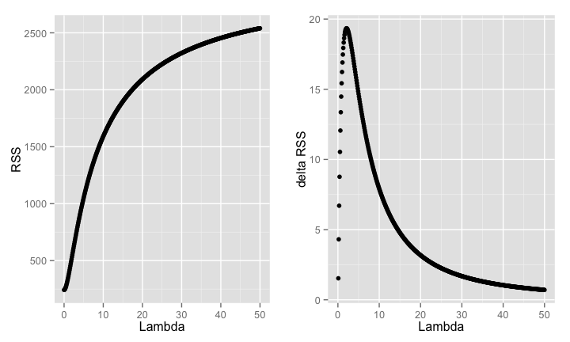

## Оценка лямбда максимизацией \(dRSS/d\lambda\)

```r
lambda.mdr <- lambdas_inc[drss==max(drss)]
lambda.mdr
```

```
## [1] 2.1
```

```r
coef(cv.fit, s=lambda.mdr)
```

```
## 5 x 1 sparse Matrix of class "dgCMatrix"
##                      1
## (Intercept)  1.9963984
## x1           1.0318885
## x2          -0.0202203
## z1           .
## z2           .
```

## Потери по сравнению с "идеальным" решением

| Модель | Лямбда | RSS/TSS | sCorr^2 | Параметры |
| --- | --- | --- | --- | --- |
| Идеальная | NA | 0.08365 | 0.917 | 2 |
| Кросс-валидация | 0 | 0.08266 | 0.9173 | 4 |
| Максимум производной | 2.1 | 0.1875 | 0.9164 | 2 |

## Свойства метода

- Метод зависит от выбора целевого показателя.

Например, вместо суммы квадратов остатков можно взять сумму квадратов модулей.

- У функции \(dRSS/d\lambda\) может быть несколько локальных максимумов

Эти слады доступны по ссылке [goo.gl/GFMeG3](https://github.com/bdemeshev/max_drss)